# Praktikum 6 Anreg

# Library

```r
library(readxl) # untuk membaca data
library(GGally) # untuk menghasilkan matriks hubungan antarpeubah
library(corrplot) # untuk menghasilkan matriks korelasi
library(dplyr) # untuk manipulasi data
library(car) # untuk memeriksa multikolinearitas
library(stargazer) # untuk menampilkan hasil perbandingan regresi
library(lmtest) # untuk uji kehomogenan ragam sisaan dan saling bebas
library(olsrr) # untuk pemeriksaan amatan tidak biasa
```

Data

```r
dt <- read_xlsx("C:\\Downloads\\Data Analisis Regresi.xlsx")
dt # menampilkan data
```

```
## # A tibble: 38 × 8
##    `Kabupaten/Kota` `Jumlah Penyakit DBD` `Indeks Pembangunan Manusia`
##    <chr>                            <dbl>                        <dbl>
##  1 Pacitan                            295                         70.2
##  2 Ponorogo                           308                         72.6
##  3 Trenggalek                         268                         71.3
##  4 Tulungagung                        410                         74.1
##  5 Blitar                             351                         72.2
##  6 Kediri                             365                         74.2
##  7 Malang                            1255                         72.2
##  8 Lumajang                           308                         68.5
##  9 Jember                             781                         69.8
## 10 Banyuwangi                         518                         73.2
## # ℹ 28 more rows
## # ℹ 5 more variables: `Persentase Penduduk Miskin` <dbl>,
## #   `Persentase RT Terhadap Sanitasi Layak` <dbl>,
## #   `Persentase RT terhadap Sumber Air Minum Layak` <dbl>,
## #   `Persentase Memiliki Jaminan Kesehatan` <dbl>, `Kepadatan Penduduk` <dbl>
```

```r
str(dt) # menampilkan tipe data setiap peubah
```

```
## tibble [38 × 8] (S3: tbl_df/tbl/data.frame)
##  $ Kabupaten/Kota                               : chr [1:38] "Pacitan" "Ponorogo" "Trenggalek" "Tulungagung" ...
##  $ Jumlah Penyakit DBD                          : num [1:38] 295 308 268 410 351 ...
##  $ Indeks Pembangunan Manusia                   : num [1:38] 70.2 72.6 71.3 74.1 72.2 ...
##  $ Persentase Penduduk Miskin                   : num [1:38] 13.8 9.32 10.96 6.71 8.71 ...
##  $ Persentase RT Terhadap Sanitasi Layak        : num [1:38] 72.6 86.8 79.3 83.6 80.1 ...
##  $ Persentase RT terhadap Sumber Air Minum Layak: num [1:38] 84 91.5 81.2 96.4 96.4 ...
##  $ Persentase Memiliki Jaminan Kesehatan        : num [1:38] 45.2 57.8 51.9 48.3 44.1 ...
##  $ Kepadatan Penduduk                           : num [1:38] 414 680 592 966 711 ...
```

```r
summary(dt) # menampilkan ringkasan data
```

```
##    Kabupaten/Kota Jumlah Penyakit DBD Indeks Pembangunan Manusia
##  Length   :38     Min.   :  57.0      Min.   :65.44
##  N.unique :38     1st Qu.: 220.0      1st Qu.:70.34
##  N.blank  : 0     Median : 300.5      Median :73.33
##  Min.nchar: 5     Mean   : 346.3      Mean   :74.00
##  Max.nchar:16     3rd Qu.: 396.5      3rd Qu.:77.23
##                   Max.   :1255.0      Max.   :83.38
##  Persentase Penduduk Miskin Persentase RT Terhadap Sanitasi Layak
##  Min.   : 3.790             Min.   :51.64
##  1st Qu.: 7.265             1st Qu.:78.37
##  Median : 9.630             Median :83.93
##  Mean   :10.326             Mean   :82.16
##  3rd Qu.:12.450             3rd Qu.:90.57
##  Max.   :21.610             Max.   :96.41
##  Persentase RT terhadap Sumber Air Minum Layak
##  Min.   : 78.56
##  1st Qu.: 94.65
##  Median : 96.38
##  Mean   : 95.36
##  3rd Qu.: 98.67
##  Max.   :100.00
##  Persentase Memiliki Jaminan Kesehatan Kepadatan Penduduk
##  Min.   :21.45                         Min.   : 414.0
##  1st Qu.:52.96                         1st Qu.: 643.0
##  Median :65.22                         Median : 913.5
##  Mean   :69.00                         Mean   :2071.1
##  3rd Qu.:91.40                         3rd Qu.:2479.8
##  Max.   :99.27                         Max.   :8595.0
```

Data yang digunakan adalah data dari 38 Kabupaten/Kota di Jawa Timur pada Tahun 2022 dengan: - Y = Jumlah Penyakit DBD - X1 = Indeks Pembangunan Manusia (IPM) - X2 = Persentase Penduduk Miskin (PM) - X3 = Persentase RT Terhadap Sanitasi Layak (RTSL) - X4 = Persentase RT Terhadap Sumber Air Minum Layak (RTAML) - X5 = Persentase Memiliki Jaminan Kesehatan (JK) - X6 = Kepadatan Penduduk (KP)

Untuk mempermudah dalam komputasi, karena peubah wilayah tidak digunakan, maka dapat dihapus.

```r
dt <- dplyr::select(dt, -`Kabupaten/Kota`)
```

# Eksplorasi Data

## Peubah Respon

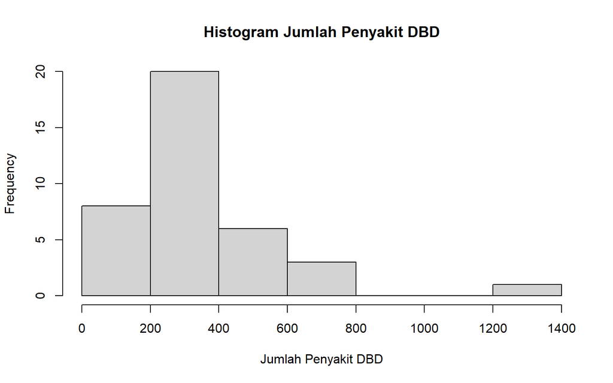

```r
hist(
  dt$`Jumlah Penyakit DBD`,
  main = "Histogram Jumlah Penyakit DBD",
  xlab = "Jumlah Penyakit DBD"
)
```

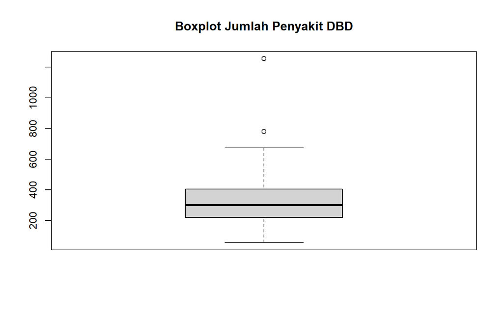

```r
boxplot(
  dt$`Jumlah Penyakit DBD`,
  main = "Boxplot Jumlah Penyakit DBD"
)
```

## Peubah Penjelas vs Peubah Respon

### IPM

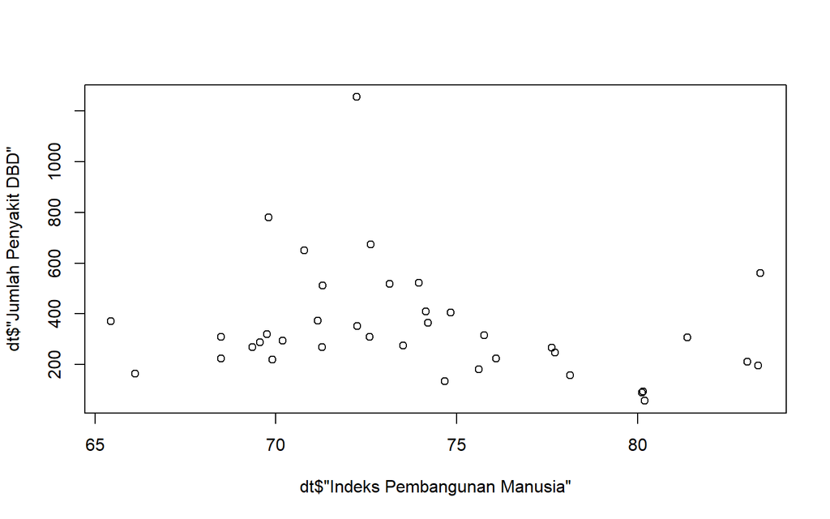

```r
plot(dt$'Indeks Pembangunan Manusia', dt$'Jumlah Penyakit DBD')
```

### PM

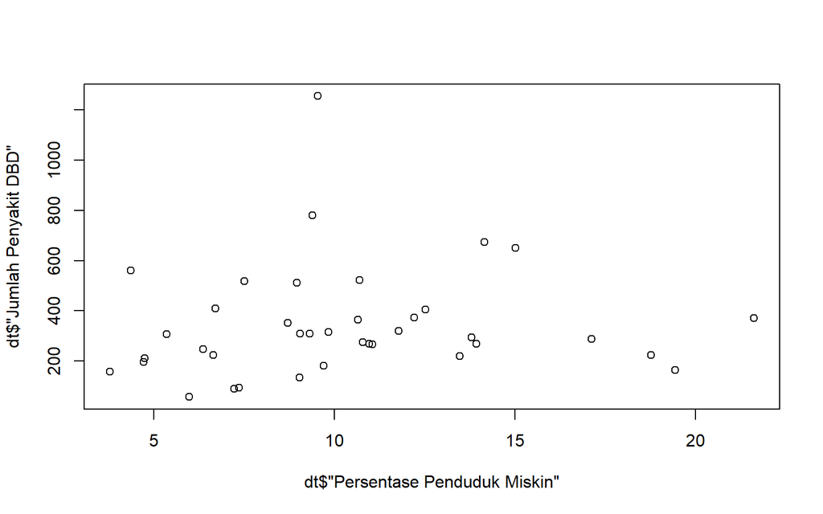

```r
plot(dt$'Persentase Penduduk Miskin', dt$'Jumlah Penyakit DBD')
```

Hubungan antara peubah PM dan Jumlah Penyakit DBD cenderung tidak linear, ada satu amatan dengan nilai X jauh dari amatan lainnya. Jika amatan tersebut disisihkan, hubungan linearitas akan lebih terlihat.

### RTSL

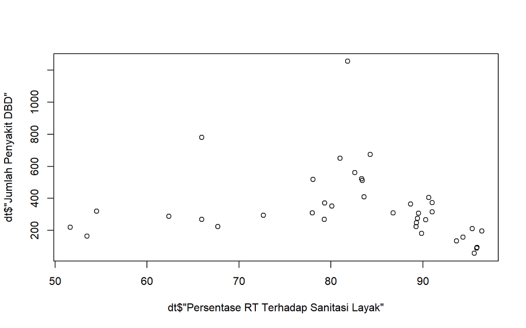

```r
plot(dt$'Persentase RT Terhadap Sanitasi Layak', dt$'Jumlah Penyakit DBD')
```

### RTAML

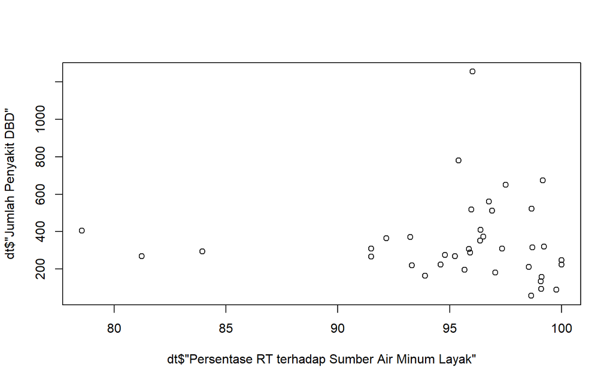

```r
plot(dt$'Persentase RT terhadap Sumber Air Minum Layak', dt$'Jumlah Penyakit DBD')
```

### JK

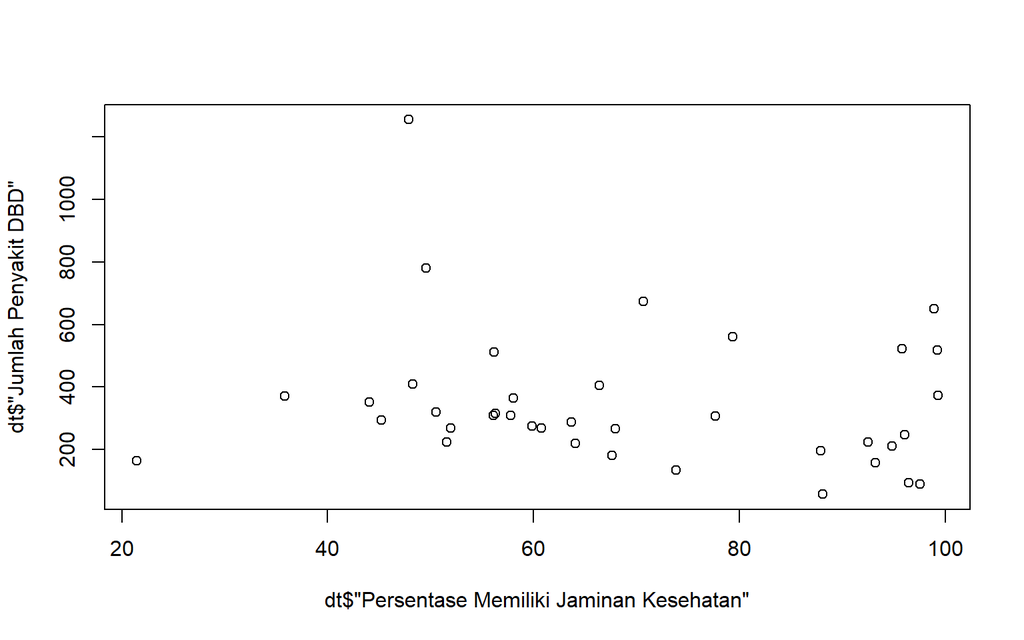

```r
plot(dt$'Persentase Memiliki Jaminan Kesehatan', dt$'Jumlah Penyakit DBD')
```

Hubungan antara peubah JK dan Jumlah Penyakit DBD cenderung tidak linear, ada satu amatan dengan nilai X jauh dari amatan lainnya. Jika amatan tersebut disisihkan, hubungan linearitas akan lebih terlihat.

### KP

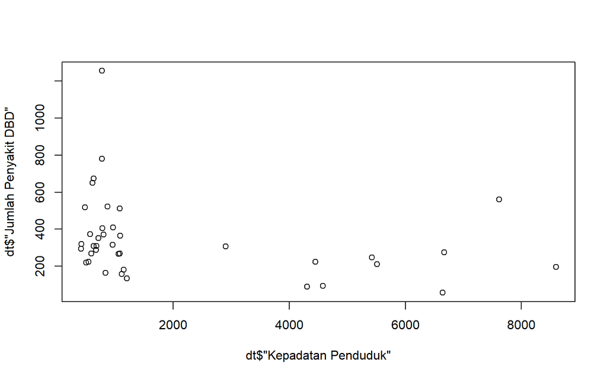

```r
plot(dt$'Kepadatan Penduduk', dt$'Jumlah Penyakit DBD')
```

## Korelasi

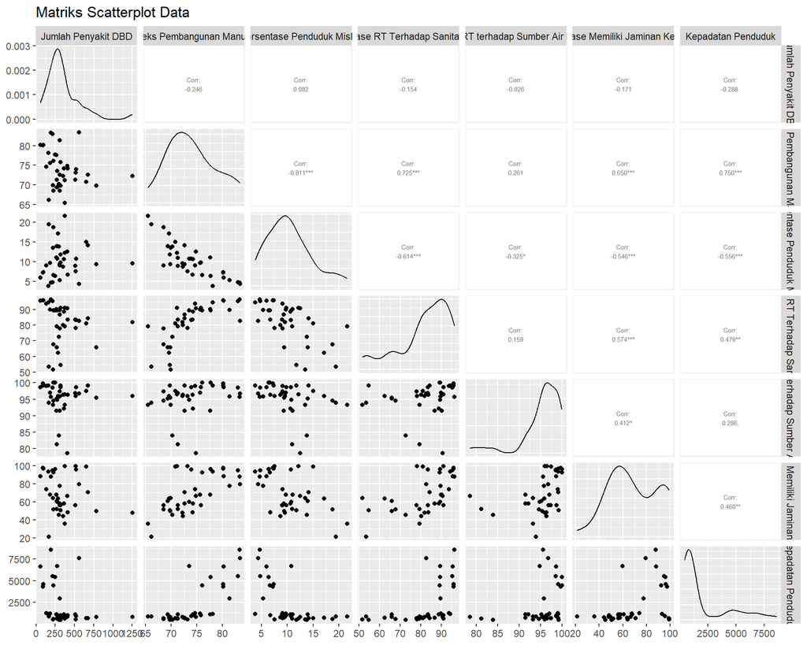

```r
ggpairs(
  dt,
  upper = list(
    continuous = wrap("cor", size = 2)
  ),
  title = "Matriks Scatterplot Data"
)
```

```r
cor_matrix <- cor(dt, use = "complete.obs")
round(cor_matrix, 2)
```

```
##                                               Jumlah Penyakit DBD
## Jumlah Penyakit DBD                                          1.00
## Indeks Pembangunan Manusia                                  -0.25
## Persentase Penduduk Miskin                                   0.08
## Persentase RT Terhadap Sanitasi Layak                       -0.15
## Persentase RT terhadap Sumber Air Minum Layak               -0.03
## Persentase Memiliki Jaminan Kesehatan                       -0.17
## Kepadatan Penduduk                                          -0.29
##                                               Indeks Pembangunan Manusia
## Jumlah Penyakit DBD                                                -0.25
## Indeks Pembangunan Manusia                                          1.00
## Persentase Penduduk Miskin                                         -0.81
## Persentase RT Terhadap Sanitasi Layak                               0.73
## Persentase RT terhadap Sumber Air Minum Layak                       0.26
## Persentase Memiliki Jaminan Kesehatan                               0.65
## Kepadatan Penduduk                                                  0.75
##                                               Persentase Penduduk Miskin
## Jumlah Penyakit DBD                                                 0.08
## Indeks Pembangunan Manusia                                         -0.81
## Persentase Penduduk Miskin                                          1.00
## Persentase RT Terhadap Sanitasi Layak                              -0.61
## Persentase RT terhadap Sumber Air Minum Layak                      -0.32
## Persentase Memiliki Jaminan Kesehatan                              -0.55
## Kepadatan Penduduk                                                 -0.56
##                                               Persentase RT Terhadap Sanitasi Layak
## Jumlah Penyakit DBD                                                           -0.15
## Indeks Pembangunan Manusia                                                     0.73
## Persentase Penduduk Miskin                                                    -0.61
## Persentase RT Terhadap Sanitasi Layak                                          1.00
## Persentase RT terhadap Sumber Air Minum Layak                                  0.16
## Persentase Memiliki Jaminan Kesehatan                                          0.57
## Kepadatan Penduduk                                                             0.48
##                                               Persentase RT terhadap Sumber Air Minum Layak
## Jumlah Penyakit DBD                                                                   -0.03
## Indeks Pembangunan Manusia                                                             0.26
## Persentase Penduduk Miskin                                                            -0.32
## Persentase RT Terhadap Sanitasi Layak                                                  0.16
## Persentase RT terhadap Sumber Air Minum Layak                                          1.00
## Persentase Memiliki Jaminan Kesehatan                                                  0.41
## Kepadatan Penduduk                                                                     0.29
##                                               Persentase Memiliki Jaminan Kesehatan
## Jumlah Penyakit DBD                                                           -0.17
## Indeks Pembangunan Manusia                                                     0.65
## Persentase Penduduk Miskin                                                    -0.55
## Persentase RT Terhadap Sanitasi Layak                                          0.57
## Persentase RT terhadap Sumber Air Minum Layak                                  0.41
## Persentase Memiliki Jaminan Kesehatan                                          1.00
## Kepadatan Penduduk                                                             0.46
##                                               Kepadatan Penduduk
## Jumlah Penyakit DBD                                        -0.29
## Indeks Pembangunan Manusia                                  0.75
## Persentase Penduduk Miskin                                 -0.56
## Persentase RT Terhadap Sanitasi Layak                       0.48
## Persentase RT terhadap Sumber Air Minum Layak               0.29
## Persentase Memiliki Jaminan Kesehatan                       0.46
## Kepadatan Penduduk                                          1.00
```

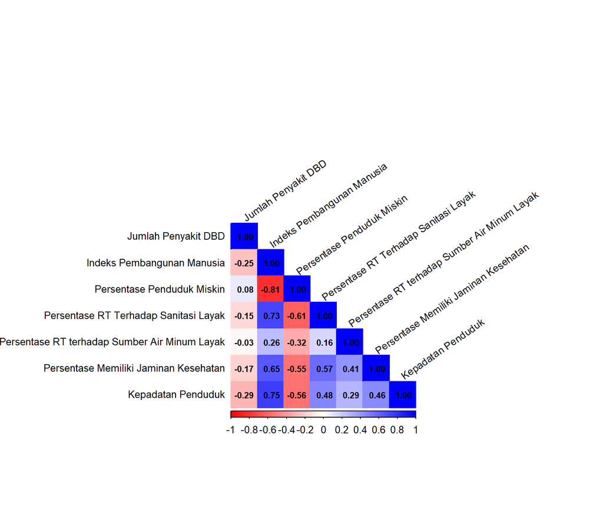

```r
corrplot(
  cor_matrix,
  method = "color",
  type = "lower",
  col = colorRampPalette(
    c("red","white","blue")
  )(200),
  addCoef.col = "black",
  tl.col = "black",
  tl.srt = 35,
  tl.cex = 0.8,
  number.cex = 0.7
)
```

Hasil matriks scatter plot dan korelasi menunjukkan bahwa peubah respon Jumlah Penyakit DBD memiliki hubungan positif dengan Persentase Penduduk Miskin (0,08), serta hubungan negatif dengan Indeks Pembangunan Manusia (IPM) (-0,25), Persentase RT terhadap Sanitasi Layak (-0,15), Persentase RT terhadap Sumber Air Minum Layak (-0,03), Persentase Memiliki Jaminan Kesehatan (-0,17), dan Kepadatan Penduduk (-0,29). Namun, berdasarkan nilai koefisien korelasi yang relatif kecil, hubungan antara Jumlah Penyakit DBD dengan seluruh peubah penjelas cenderung lemah.

Selain itu, terdapat beberapa korelasi yang cukup tinggi antar peubah penjelas, baik positif maupun negatif. Beberapa di antaranya adalah: 1. IPM dan Persentase Penduduk Miskin memiliki korelasi negatif yang sangat kuat sebesar -0,81. 2. IPM dan Persentase RT terhadap Sanitasi Layak memiliki korelasi positif kuat sebesar 0,73. 3. IPM dan Kepadatan Penduduk memiliki korelasi positif kuat sebesar 0,75. 4. Persentase Penduduk Miskin dan Persentase RT terhadap Sanitasi Layak memiliki korelasi negatif kuat sebesar -0,61. 5. IPM dan Persentase Memiliki Jaminan Kesehatan memiliki korelasi positif sebesar 0,65. 6. Persentase Penduduk Miskin dan Persentase Memiliki Jaminan Kesehatan memiliki korelasi negatif sebesar -0,55. 7. Persentase Penduduk Miskin dan Kepadatan Penduduk memiliki korelasi negatif sebesar -0,56. 8. Persentase RT terhadap Sanitasi Layak dan Persentase Memiliki Jaminan Kesehatan memiliki korelasi positif sebesar 0,57.

Korelasi yang cukup tinggi antar beberapa peubah penjelas tersebut mengindikasikan adanya potensi multikolinearitas dalam data. Kondisi ini dapat menyebabkan ketidakstabilan estimasi parameter regresi serta menurunkan kemampuan model dalam mengidentifikasi pengaruh masing-masing peubah penjelas secara akurat. Oleh karena itu, diperlukan pemeriksaan lebih lanjut, misalnya menggunakan Variance Inflation Factor (VIF) atau metode penanganan multikolinearitas lainnya.

# Pemodelan

```r
model1 <- lm(`Jumlah Penyakit DBD` ~ ., data = dt)
summary(model1)
```

```
##
## Call:
## lm(formula = `Jumlah Penyakit DBD` ~ ., data = dt)
##
## Residuals:
##     Min      1Q  Median      3Q     Max
## -248.22 -118.92  -38.49   35.63  829.11
##
## Coefficients:
##                                                   Estimate Std. Error t value
## (Intercept)                                     1488.56857 1820.93820   0.817
## `Indeks Pembangunan Manusia`                     -14.96729   20.57704  -0.727
## `Persentase Penduduk Miskin`                     -15.65148   15.63992  -1.001
## `Persentase RT Terhadap Sanitasi Layak`            0.38271    4.58716   0.083
## `Persentase RT terhadap Sumber Air Minum Layak`    1.91090    8.96458   0.213
## `Persentase Memiliki Jaminan Kesehatan`           -0.65697    2.58738  -0.254
## `Kepadatan Penduduk`                              -0.01998    0.02515  -0.794
##                                                 Pr(>|t|)
## (Intercept)                                        0.420
## `Indeks Pembangunan Manusia`                       0.472
## `Persentase Penduduk Miskin`                       0.325
## `Persentase RT Terhadap Sanitasi Layak`            0.934
## `Persentase RT terhadap Sumber Air Minum Layak`    0.833
## `Persentase Memiliki Jaminan Kesehatan`            0.801
## `Kepadatan Penduduk`                               0.433
##
## Residual standard error: 228.9 on 31 degrees of freedom
## Multiple R-squared:   0.12,  Adjusted R-squared:  -0.05032
## F-statistic: 0.7046 on 6 and 31 DF,  p-value: 0.6482
```

Persamaan yang terbentuk adalah
$$\hat{JPD}=1488.57−14.97IPM−15.65PM+0.38RTSL+1.91RTAML-0.66JK-0.02KP$$

Berdasarkan persamaan regresi yang diperoleh, peubah Indeks Pembangunan Manusia (IPM), Persentase Penduduk Miskin (PM), Persentase Memiliki Jaminan Kesehatan (JK), dan Kepadatan Penduduk (KP) memiliki koefisien regresi bernilai negatif. Hal ini menunjukkan bahwa peningkatan nilai peubah-peubah tersebut cenderung diikuti oleh penurunan jumlah kasus DBD dengan asumsi peubah lain konstan. Sebaliknya, Persentase Rumah Tangga yang Memiliki Akses terhadap Sanitasi Layak (RTSL) dan Persentase Rumah Tangga yang Memiliki Akses terhadap Sumber Air Minum Layak (RTAML) memiliki koefisien regresi positif, yang mengindikasikan bahwa peningkatan kedua peubah tersebut cenderung diikuti oleh peningkatan jumlah kasus DBD dengan asumsi peubah lain tetap. Berdasarkan hasil matriks korelasi sebelumnya, terdapat beberapa peubah yang mengalami perubahan arah hubungan jika dibandingkan dengan tanda koefisien regresinya. Sebagai contoh, Persentase Penduduk Miskin (PM) memiliki korelasi positif terhadap Jumlah Penyakit DBD, namun koefisien regresinya bernilai negatif. Selain itu, Persentase Rumah Tangga yang Memiliki Akses terhadap Sanitasi Layak (RTSL) dan Persentase Rumah Tangga yang Memiliki Akses terhadap Sumber Air Minum Layak (RTAML) memiliki korelasi negatif terhadap Jumlah Penyakit DBD, tetapi koefisien regresinya justru bernilai positif. Perubahan tanda tersebut mengindikasikan adanya kemungkinan permasalahan dalam model, salah satunya akibat hubungan yang cukup kuat antar peubah penjelas (multikolinearitas).

# Pemeriksaan Multikolinearitas

## Perubahan Peubah

```r
names(dt)
```

```
## [1] "Jumlah Penyakit DBD"
## [2] "Indeks Pembangunan Manusia"
## [3] "Persentase Penduduk Miskin"
## [4] "Persentase RT Terhadap Sanitasi Layak"
## [5] "Persentase RT terhadap Sumber Air Minum Layak"
## [6] "Persentase Memiliki Jaminan Kesehatan"
## [7] "Kepadatan Penduduk"
```

```r
mod1 <- lm(`Jumlah Penyakit DBD` ~ `Indeks Pembangunan Manusia`,
           data = dt)

mod2 <- lm(`Jumlah Penyakit DBD` ~
             `Indeks Pembangunan Manusia` +
             `Persentase Penduduk Miskin`,
           data = dt)

mod3 <- lm(`Jumlah Penyakit DBD` ~
             `Indeks Pembangunan Manusia` +
             `Persentase Penduduk Miskin` +
             `Persentase RT Terhadap Sanitasi Layak`,
           data = dt)

mod4 <- lm(`Jumlah Penyakit DBD` ~
             `Indeks Pembangunan Manusia` +
             `Persentase Penduduk Miskin` +
             `Persentase RT Terhadap Sanitasi Layak` +
             `Persentase RT terhadap Sumber Air Minum Layak`,
           data = dt)

mod5 <- lm(`Jumlah Penyakit DBD` ~
             `Indeks Pembangunan Manusia` +
             `Persentase Penduduk Miskin` +
             `Persentase RT Terhadap Sanitasi Layak` +
             `Persentase RT terhadap Sumber Air Minum Layak` +
             `Persentase Memiliki Jaminan Kesehatan`,
           data = dt)

mod6 <- lm(`Jumlah Penyakit DBD` ~ .,
           data = dt)

stargazer(mod1, mod2, mod3, mod4, mod5, mod6,
          type = "text", single.row = TRUE)
```

```
##
## ========================================================================================================================================================================================
##                                                                                                           Dependent variable:
##                                                 ----------------------------------------------------------------------------------------------------------------------------------------
##                                                                                                          `Jumlah Penyakit DBD`
##                                                          (1)                    (2)                     (3)                    (4)                    (5)                   (6)
## ----------------------------------------------------------------------------------------------------------------------------------------------------------------------------------------
## `Indeks Pembangunan Manusia`                       -11.598 (7.628)       -24.734* (12.935)       -25.736* (15.078)       -25.737 (15.310)      -24.794 (16.347)      -14.967 (20.577)
## `Persentase Penduduk Miskin`                                             -17.946 (14.329)        -17.821 (14.564)        -17.813 (15.099)      -17.693 (15.338)      -15.651 (15.640)
## `Persentase RT Terhadap Sanitasi Layak`                                                            0.577 (4.280)          0.578 (4.352)          0.768 (4.535)         0.383 (4.587)
## `Persentase RT terhadap Sumber Air Minum Layak`                                                                           0.020 (8.093)          0.583 (8.756)         1.911 (8.965)
## `Persentase Memiliki Jaminan Kesehatan`                                                                                                         -0.476 (2.562)        -0.657 (2.587)
## `Kepadatan Penduduk`                                                                                                                                                  -0.020 (0.025)
## Constant                                        1,204.573** (565.630) 2,362.034** (1,081.270) 2,387.460** (1,112.866) 2,385.463* (1,381.374) 2,277.932 (1,517.031) 1,488.569 (1,820.938)
## ----------------------------------------------------------------------------------------------------------------------------------------------------------------------------------------
## Observations                                             38                     38                      38                      38                    38                    38
## R2                                                      0.060                  0.101                   0.101                  0.101                  0.102                 0.120
## Adjusted R2                                             0.034                  0.049                   0.022                  -0.008                -0.038                -0.050
## Residual Std. Error                               219.497 (df = 36)      217.785 (df = 35)       220.905 (df = 34)      224.227 (df = 33)      227.581 (df = 32)     228.905 (df = 31)
## F Statistic                                      2.312 (df = 1; 36)     1.958 (df = 2; 35)      1.275 (df = 3; 34)      0.928 (df = 4; 33)    0.728 (df = 5; 32)    0.705 (df = 6; 31)
## ========================================================================================================================================================================================
## Note:                                                                                                                                                        *p<0.1; **p<0.05; ***p<0.01
```

## Perubahan Banyak Data

```r
mod6 <- lm(`Jumlah Penyakit DBD` ~ .,
           data = dt)
stargazer(summary(mod5)$coefficients, summary(mod6)$coefficients,
          type = "text",
          font.size = "small")
```

```
##
## ========================================================================================
##                                                 Estimate  Std. Error t value Pr(> | t| )
## ----------------------------------------------------------------------------------------
## (Intercept)                                     2,277.932 1,517.031   1.502     0.143
## `Indeks Pembangunan Manusia`                     -24.794    16.347   -1.517     0.139
## `Persentase Penduduk Miskin`                     -17.693    15.338   -1.154     0.257
## `Persentase RT Terhadap Sanitasi Layak`           0.768     4.535     0.169     0.867
## `Persentase RT terhadap Sumber Air Minum Layak`   0.583     8.756     0.067     0.947
## `Persentase Memiliki Jaminan Kesehatan`          -0.476     2.562    -0.186     0.854
## ----------------------------------------------------------------------------------------
##
## ========================================================================================
##                                                 Estimate  Std. Error t value Pr(> | t| )
## ----------------------------------------------------------------------------------------
## (Intercept)                                     1,488.569 1,820.938   0.817     0.420
## `Indeks Pembangunan Manusia`                     -14.967    20.577   -0.727     0.472
## `Persentase Penduduk Miskin`                     -15.651    15.640   -1.001     0.325
## `Persentase RT Terhadap Sanitasi Layak`           0.383     4.587     0.083     0.934
## `Persentase RT terhadap Sumber Air Minum Layak`   1.911     8.965     0.213     0.833
## `Persentase Memiliki Jaminan Kesehatan`          -0.657     2.587    -0.254     0.801
## `Kepadatan Penduduk`                             -0.020     0.025    -0.794     0.433
## ----------------------------------------------------------------------------------------
```

## Akar Ciri

```r
x <- dt[-1]
r <- cor(x)
(ev <- eigen(r)$values)
```

```
## [1] 3.6422879 0.9229115 0.5785734 0.4177190 0.3329154 0.1055928
```

```r
# Simultan
if ((max(ev) / min(ev)) <= 100) {
  cat("Tidak ada multikolinearitas\n")
} else if ((max(ev) / min(ev)) > 100 & (max(ev) / min(ev)) <= 1000) {
  cat("Ada multikolinearitas yang lemah\n")
} else {
  cat("Ada multikolinearitas yang kuat\n")
}
```

```
## Tidak ada multikolinearitas
```

```r
# Parsial
if (all((max(ev) / ev) <= 1000)) {
  cat("Tidak ada multikolinearitas\n")
} else {
  cat("Ada multikolinearitas pada peubah penjelas ke:", which((max(ev) / ev) > 1000), "\n")
}
```

```
## Tidak ada multikolinearitas
```

## Nilai VIF

```r
vif(model1)
```

```
##                    `Indeks Pembangunan Manusia`
##                                        6.691048
##                    `Persentase Penduduk Miskin`
##                                        3.149630
##         `Persentase RT Terhadap Sanitasi Layak`
##                                        2.267094
## `Persentase RT terhadap Sumber Air Minum Layak`
##                                        1.320882
##         `Persentase Memiliki Jaminan Kesehatan`
##                                        2.065353
##                            `Kepadatan Penduduk`
##                                        2.460525
```

Kriteria umum:

- VIF < 5 : Tidak ada multikolinearitas serius
- 5 ≤ VIF < 10 : Multikolinearitas sedang
- VIF ≥ 10 : Multikolinearitas tinggi

Hasil uji ini menunjukkan peubah IPM memiliki nilai VIF yang cenderung tinggi (>5). Sementara itu, peubah Persentase Penduduk Miskin, Persentase RT terhadap Sanitasi Layak, Persentase RT terhadap Sumber Air Minum Layak, Persentase Memiliki Jaminan Kesehatan, dan Kepadatan Penduduk memiliki nilai VIF yang rendah hingga sedang (1.31–3.15) dan masih berada dalam batas aman (<5), sehingga tidak menunjukkan masalah multikolinearitas yang serius.

# Pemodelan Penyisihan Peubah

```r
model1 <- lm(`Jumlah Penyakit DBD` ~ ., data = dt)
summary(model1)
```

```
##
## Call:
## lm(formula = `Jumlah Penyakit DBD` ~ ., data = dt)
##
## Residuals:
##     Min      1Q  Median      3Q     Max
## -248.22 -118.92  -38.49   35.63  829.11
##
## Coefficients:
##                                                   Estimate Std. Error t value
## (Intercept)                                     1488.56857 1820.93820   0.817
## `Indeks Pembangunan Manusia`                     -14.96729   20.57704  -0.727
## `Persentase Penduduk Miskin`                     -15.65148   15.63992  -1.001
## `Persentase RT Terhadap Sanitasi Layak`            0.38271    4.58716   0.083
## `Persentase RT terhadap Sumber Air Minum Layak`    1.91090    8.96458   0.213
## `Persentase Memiliki Jaminan Kesehatan`           -0.65697    2.58738  -0.254
## `Kepadatan Penduduk`                              -0.01998    0.02515  -0.794
##                                                 Pr(>|t|)
## (Intercept)                                        0.420
## `Indeks Pembangunan Manusia`                       0.472
## `Persentase Penduduk Miskin`                       0.325
## `Persentase RT Terhadap Sanitasi Layak`            0.934
## `Persentase RT terhadap Sumber Air Minum Layak`    0.833
## `Persentase Memiliki Jaminan Kesehatan`            0.801
## `Kepadatan Penduduk`                               0.433
##
## Residual standard error: 228.9 on 31 degrees of freedom
## Multiple R-squared:   0.12,  Adjusted R-squared:  -0.05032
## F-statistic: 0.7046 on 6 and 31 DF,  p-value: 0.6482
```

```r
model2 <- lm(
  `Jumlah Penyakit DBD` ~
  `Indeks Pembangunan Manusia` +
  `Persentase Penduduk Miskin` +
  `Persentase RT terhadap Sumber Air Minum Layak` +
  `Persentase Memiliki Jaminan Kesehatan` +
  `Kepadatan Penduduk`,
  data = dt
)

summary(model2)
```

```
##
## Call:
## lm(formula = `Jumlah Penyakit DBD` ~ `Indeks Pembangunan Manusia` +
##     `Persentase Penduduk Miskin` + `Persentase RT terhadap Sumber Air Minum Layak` +
##     `Persentase Memiliki Jaminan Kesehatan` + `Kepadatan Penduduk`,
##     data = dt)
##
## Residuals:
##     Min      1Q  Median      3Q     Max
## -244.45 -120.34  -40.63   37.31  830.78
##
## Coefficients:
##                                                   Estimate Std. Error t value
## (Intercept)                                     1478.89157 1788.82140   0.827
## `Indeks Pembangunan Manusia`                     -14.33115   18.81335  -0.762
## `Persentase Penduduk Miskin`                     -15.73339   15.36497  -1.024
## `Persentase RT terhadap Sumber Air Minum Layak`    1.82853    8.77070   0.208
## `Persentase Memiliki Jaminan Kesehatan`           -0.61054    2.48731  -0.245
## `Kepadatan Penduduk`                              -0.02020    0.02462  -0.821
##                                                 Pr(>|t|)
## (Intercept)                                        0.415
## `Indeks Pembangunan Manusia`                       0.452
## `Persentase Penduduk Miskin`                       0.314
## `Persentase RT terhadap Sumber Air Minum Layak`    0.836
## `Persentase Memiliki Jaminan Kesehatan`            0.808
## `Kepadatan Penduduk`                               0.418
##
## Residual standard error: 225.3 on 32 degrees of freedom
## Multiple R-squared:  0.1198, Adjusted R-squared:  -0.01773
## F-statistic: 0.8711 on 5 and 32 DF,  p-value: 0.5113
```

```r
model3 <- lm(
`Jumlah Penyakit DBD` ~
`Indeks Pembangunan Manusia` +
`Persentase Penduduk Miskin` +
`Persentase Memiliki Jaminan Kesehatan` +
`Kepadatan Penduduk`,
data = dt
)

summary(model3)
```

```
##
## Call:
## lm(formula = `Jumlah Penyakit DBD` ~ `Indeks Pembangunan Manusia` +
##     `Persentase Penduduk Miskin` + `Persentase Memiliki Jaminan Kesehatan` +
##     `Kepadatan Penduduk`, data = dt)
##
## Residuals:
##     Min      1Q  Median      3Q     Max
## -240.67 -137.03  -35.55   38.69  834.86
##
## Coefficients:
##                                           Estimate Std. Error t value Pr(>|t|)
## (Intercept)                             1715.19844 1363.67882   1.258    0.217
## `Indeks Pembangunan Manusia`             -15.26185   18.00920  -0.847    0.403
## `Persentase Penduduk Miskin`             -16.45218   14.75455  -1.115    0.273
## `Persentase Memiliki Jaminan Kesehatan`   -0.43330    2.30339  -0.188    0.852
## `Kepadatan Penduduk`                      -0.01917    0.02376  -0.807    0.426
##
## Residual standard error: 222 on 33 degrees of freedom
## Multiple R-squared:  0.1186, Adjusted R-squared:  0.01177
## F-statistic:  1.11 on 4 and 33 DF,  p-value: 0.3683
```

```r
model4 <- lm(
  `Jumlah Penyakit DBD` ~
    `Indeks Pembangunan Manusia` +
    `Persentase Penduduk Miskin` +
    `Kepadatan Penduduk`,
  data = dt
)

summary(model4)
```

```
##
## Call:
## lm(formula = `Jumlah Penyakit DBD` ~ `Indeks Pembangunan Manusia` +
##     `Persentase Penduduk Miskin` + `Kepadatan Penduduk`, data = dt)
##
## Residuals:
##     Min      1Q  Median      3Q     Max
## -245.10 -134.44  -34.75   41.43  842.14
##
## Coefficients:
##                                Estimate Std. Error t value Pr(>|t|)
## (Intercept)                  1776.58658 1305.13895   1.361    0.182
## `Indeks Pembangunan Manusia`  -16.51566   16.49139  -1.001    0.324
## `Persentase Penduduk Miskin`  -16.35152   14.53417  -1.125    0.268
## `Kepadatan Penduduk`           -0.01895    0.02340  -0.810    0.424
##
## Residual standard error: 218.9 on 34 degrees of freedom
## Multiple R-squared:  0.1177, Adjusted R-squared:  0.03981
## F-statistic: 1.511 on 3 and 34 DF,  p-value: 0.2292
```

```r
model5 <- lm(
  `Jumlah Penyakit DBD` ~
    `Indeks Pembangunan Manusia` +
    `Persentase Penduduk Miskin`,
  data = dt
)

summary(model5)
```

```
##
## Call:
## lm(formula = `Jumlah Penyakit DBD` ~ `Indeks Pembangunan Manusia` +
##     `Persentase Penduduk Miskin`, data = dt)
##
## Residuals:
##     Min      1Q  Median      3Q     Max
## -219.14 -136.03  -57.48   46.94  850.91
##
## Coefficients:
##                              Estimate Std. Error t value Pr(>|t|)
## (Intercept)                   2362.03    1081.27   2.185   0.0357 *
## `Indeks Pembangunan Manusia`   -24.73      12.93  -1.912   0.0641 .
## `Persentase Penduduk Miskin`   -17.95      14.33  -1.252   0.2187
## ---
## Signif. codes:  0 '***' 0.001 '**' 0.01 '*' 0.05 '.' 0.1 ' ' 1
##
## Residual standard error: 217.8 on 35 degrees of freedom
## Multiple R-squared:  0.1006, Adjusted R-squared:  0.04925
## F-statistic: 1.958 on 2 and 35 DF,  p-value: 0.1562
```

## Nilai VIF

```r
vif(model2)
```

```
##                    `Indeks Pembangunan Manusia`
##                                        5.772334
##                    `Persentase Penduduk Miskin`
##                                        3.137218
## `Persentase RT terhadap Sumber Air Minum Layak`
##                                        1.304858
##         `Persentase Memiliki Jaminan Kesehatan`
##                                        1.969811
##                            `Kepadatan Penduduk`
##                                        2.432977
```

# Pengujian Asumsi

## Eksplorasi Grafik

### Plot Sisaan vs Y duga

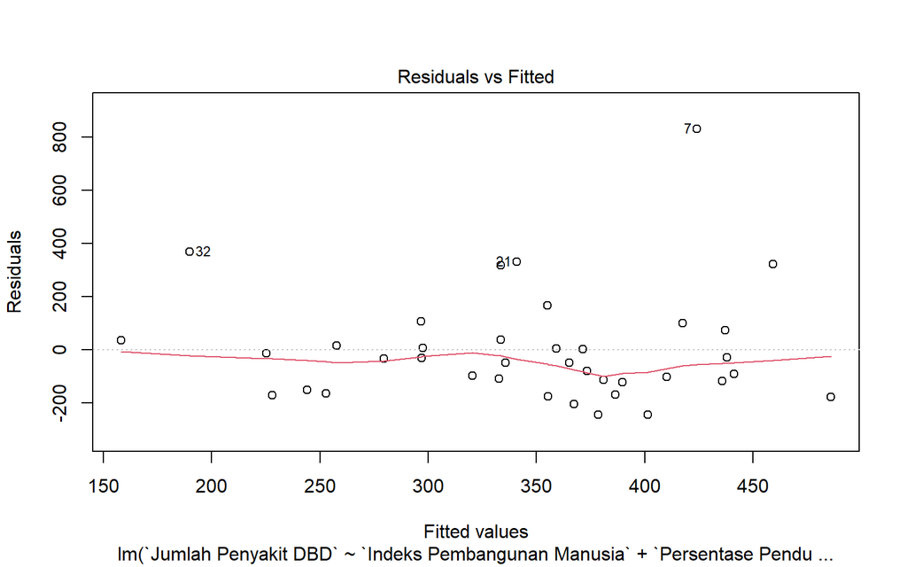

```r
plot(model2,1)
```

### Plot Sisaan vs Urutan

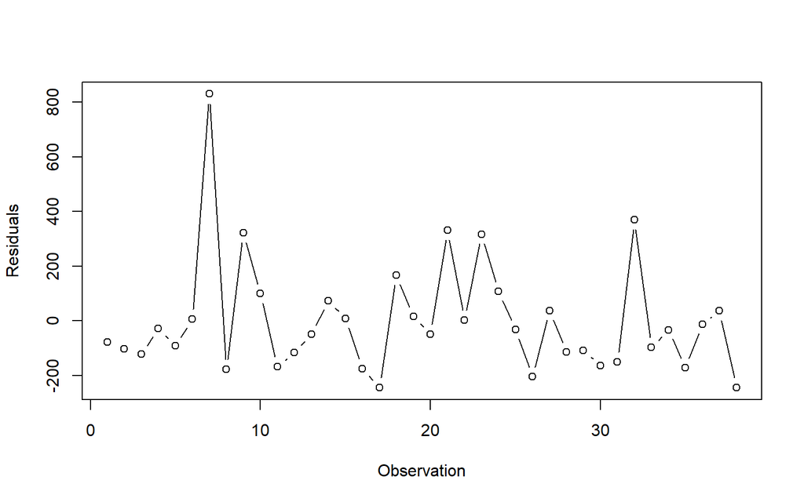

```r
plot(x = 1:dim(dt)[1],
     y = model2$residuals,
     type = 'b',
     ylab = "Residuals",
     xlab = "Observation")
```

### QQ plot

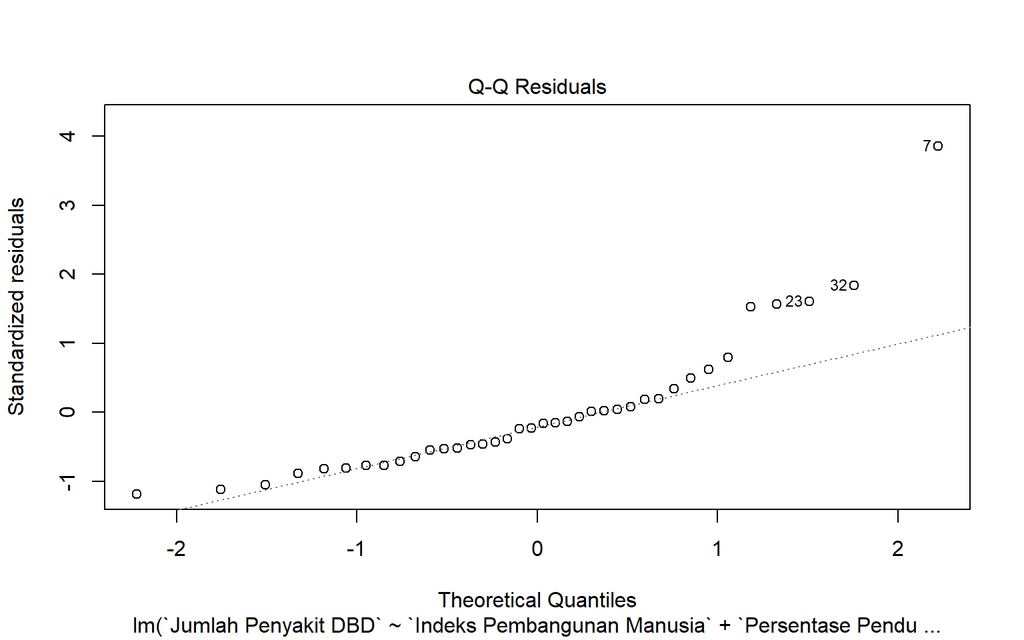

```r
plot(model2,2)
```

## Uji Formal

### Nilai harapan sisaan sama dengan nol

```r
t.test(model2$residuals,mu = 0,conf.level = 0.95)
```

```
##
##  One Sample t-test
##
## data:  model2$residuals
## t = -2.6403e-16, df = 37, p-value = 1
## alternative hypothesis: true mean is not equal to 0
## 95 percent confidence interval:
##  -68.87684  68.87684
## sample estimates:
##     mean of x
## -8.975277e-15
```

Nilai p pada uji t sama dengan 1 yang lebih besar dari alpha 5%, sehingga dinyatakan asumsi nilai harapan sisaan sama dengan nol terpenuhi

### Ragam sisaan homogen

```r
bptest(model2)
```

```
##
##  studentized Breusch-Pagan test
##
## data:  model2
## BP = 2.2674, df = 5, p-value = 0.811
```

Nilai p pada uji breusch pagan sama dengan 0.811 yang lebih besar dari alpha 5%, sehingga dinyatakan asumsi ragam sisaan homogen terpenuhi

### Sisaan saling bebas

```r
dwtest(model2)
```

```
##
##  Durbin-Watson test
##
## data:  model2
## DW = 2.1564, p-value = 0.5603
## alternative hypothesis: true autocorrelation is greater than 0
```

Nilai p pada uji durbin watson sama dengan 0.5603 yang lebih besar dari alpha 5%, sehingga dinyatakan asumsi sisaan saling bebas terpenuhi

### Normalitas Sisaan

```r
shapiro.test(model2$residuals)
```

```
##
##  Shapiro-Wilk normality test
##
## data:  model2$residuals
## W = 0.81705, p-value = 2.37e-05
```

# Pemeriksaan Amatan Tidak Biasa

```r
#fungsi
ri_stud <- rstudent(model2)
ri_stan <- rstandard(model2)
hii_fungsi <- hatvalues(model2)

#manual
X <- model.matrix(model2)
X_inv_xt <- X %*% solve(t(X) %*% X) %*% t(X)
hii_manual <- diag(X_inv_xt)
anova_model <- anova(model2)
s <- sqrt(anova_model["Residuals", "Mean Sq"])
ei <- model2$residuals
ri_manual <- ei/(s*sqrt(1-hii_manual))

nilai <- data.frame(ri_stud, ri_stan, ri_manual, hii_fungsi, hii_manual)
nilai
```

```
##        ri_stud     ri_stan   ri_manual hii_fungsi hii_manual
## 1  -0.37917758 -0.38435454 -0.38435454 0.18046418 0.18046418
## 2  -0.46574147 -0.47154691 -0.47154691 0.07388430 0.07388430
## 3  -0.64128900 -0.64727101 -0.64727101 0.30251809 0.30251809
## 4  -0.13312300 -0.13521446 -0.13521446 0.15098218 0.15098218
## 5  -0.42372923 -0.42926800 -0.42926800 0.12684478 0.12684478
## 6   0.02649516  0.02691880  0.02691880 0.05921411 0.05921411
## 7   5.20539541  3.86327007  3.86327007 0.08915334 0.08915334
## 8  -0.87946937 -0.88259896 -0.88259896 0.19949250 0.19949250
## 9   1.56345632  1.52932245  1.52932245 0.12878526 0.12878526
## 10  0.49490456  0.50084882  0.50084882 0.20794222 0.20794222
## 11 -0.75942510 -0.76449805 -0.76449805 0.05526010 0.05526010
## 12 -0.53705609 -0.54312870 -0.54312870 0.10251185 0.10251185
## 13 -0.22649371 -0.22992767 -0.22992767 0.11981712 0.11981712
## 14  0.33853881  0.34332172  0.34332172 0.09170690 0.09170690
```

[output cut: 24 more lines]

## Pencilan

```r
for (i in 1:dim(nilai)[1]){
  absri <- abs(nilai[,2])
  pencilan <- which(absri > 2)
}
pencilan
```

```
## [1] 7
```

Amatan ke-7 terdeteksi sebagai pencilan

## Leverage

```r
n <- dim(dt)[1]
p <- length(model2$coefficients)

for (i in 1:dim(nilai)[1]){
  cutoff <- 2*p/n
  titik_leverage <- which(hii_fungsi > cutoff)
}
titik_leverage
```

```
## 24
## 24
```

Amatan ke-24 terdeteksi sebagai titik leverage

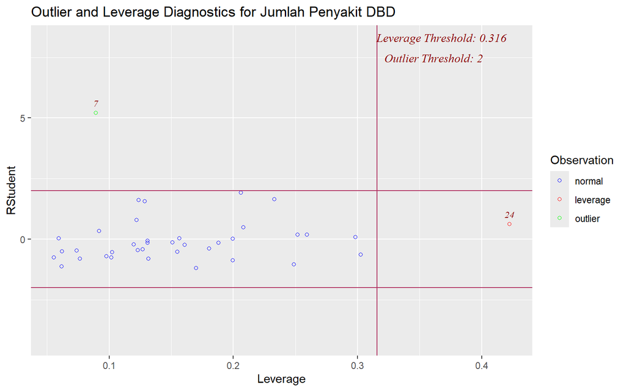

```r
ols_plot_resid_lev(model2)
```

Plot yang terbentuk dari fungsi ols_plot_resid_lev() menunjukkan adanya satu pencilan (outlier), yaitu amatan ke-7, dan satu amatan dengan leverage tinggi, yaitu amatan ke-24. Amatan ke-7 dikategorikan sebagai pencilan karena memiliki nilai studentized residual (RStudent) yang melebihi batas outlier threshold sebesar ±2. Di sisi lain, amatan ke-24 memiliki nilai leverage yang melampaui batas leverage threshold sebesar 0,316 sehingga termasuk amatan berpengaruh dari sisi nilai prediktornya. Meskipun demikian, nilai RStudent amatan ke-24 masih berada dalam rentang yang diperbolehkan sehingga tidak termasuk pencilan. Dengan demikian, amatan ke-7 merupakan observasi yang paling perlu diperhatikan karena memiliki penyimpangan yang cukup besar terhadap pola umum data.

## Amatan Berpengaruh

### Jarak Cook

```r
di <- cooks.distance(model2)
f <- qf(0.05,p,n-p, lower.tail = F)
data.frame(di, di>f)
```

```
##              di di...f
## 1  5.421705e-03  FALSE
## 2  2.956552e-03  FALSE
## 3  3.028583e-02  FALSE
## 4  5.418809e-04  FALSE
## 5  4.461562e-03  FALSE
## 6  7.601417e-06  FALSE
## 7  2.434732e-01  FALSE
## 8  3.235465e-02  FALSE
## 9  5.762193e-02  FALSE
## 10 1.097610e-02  FALSE
## 11 5.697717e-03  FALSE
## 12 5.615644e-03  FALSE
## 13 1.199436e-03  FALSE
## 14 1.983478e-03  FALSE
```

[output cut: 24 more lines]

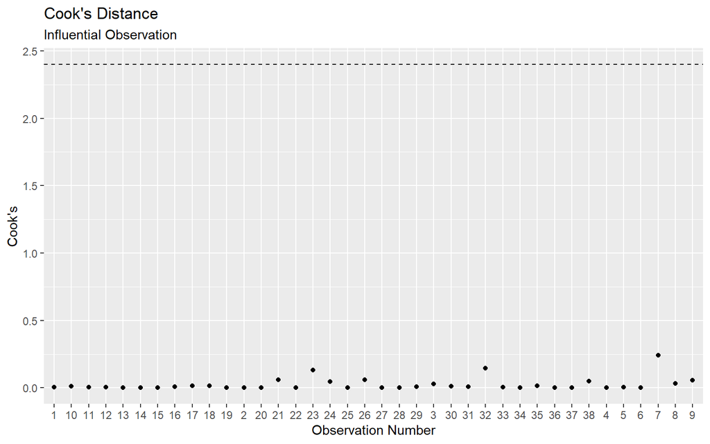

```r
cooks_crit = f
model_cooks <- cooks.distance(model2)
df <- data.frame(obs = names(model_cooks),
                 cooks = model_cooks)
ggplot(df, aes(y = cooks, x = obs)) +
  geom_point() +
  geom_hline(yintercept = cooks_crit, linetype="dashed") +
  labs(title = "Cook's Distance",
       subtitle = "Influential Observation ",
       x = "Observation Number",
       y = "Cook's")
```

Pemeriksaan amatan berpengaruh dengan jarak cook tidak dihasilkan nilai yang melebihi ambang batas

### DFBETAS

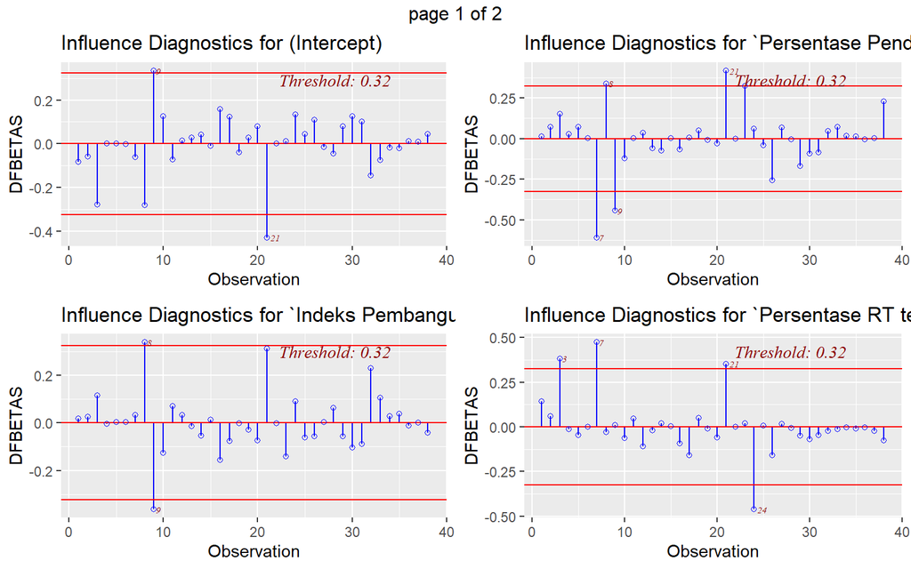

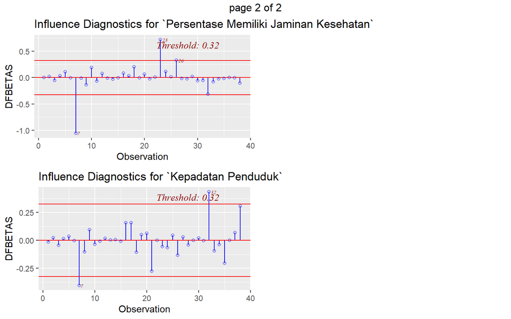

```r
ols_plot_dfbetas(model2)
```

Hasil DFBETAS akan menunjukkan pengaruh observasi terhadap setiap koefisien regresi, sehingga ada output untuk setiap parameter regresi. DFBETAS mengukur seberapa besar koefisien regresi berubah jika suatu observasi dihapus dari model. Berdasarkan plot DFBETAS, amatan ke-7 merupakan observasi yang paling konsisten menunjukkan pengaruh besar terhadap koefisien regresi karena melewati ambang batas pada kedua variabel. Selain itu, amatan ke-23 berpengaruh terhadap koefisien variabel Persentase Memiliki Jaminan Kesehatan, sedangkan amatan ke-32 berpengaruh terhadap koefisien variabel Kepadatan Penduduk. Dengan demikian, amatan ke-7, ke-23, dan ke-32 dapat dikategorikan sebagai observasi yang perlu ditinjau lebih lanjut karena berpotensi memengaruhi hasil estimasi model regresi. ### DFFITS

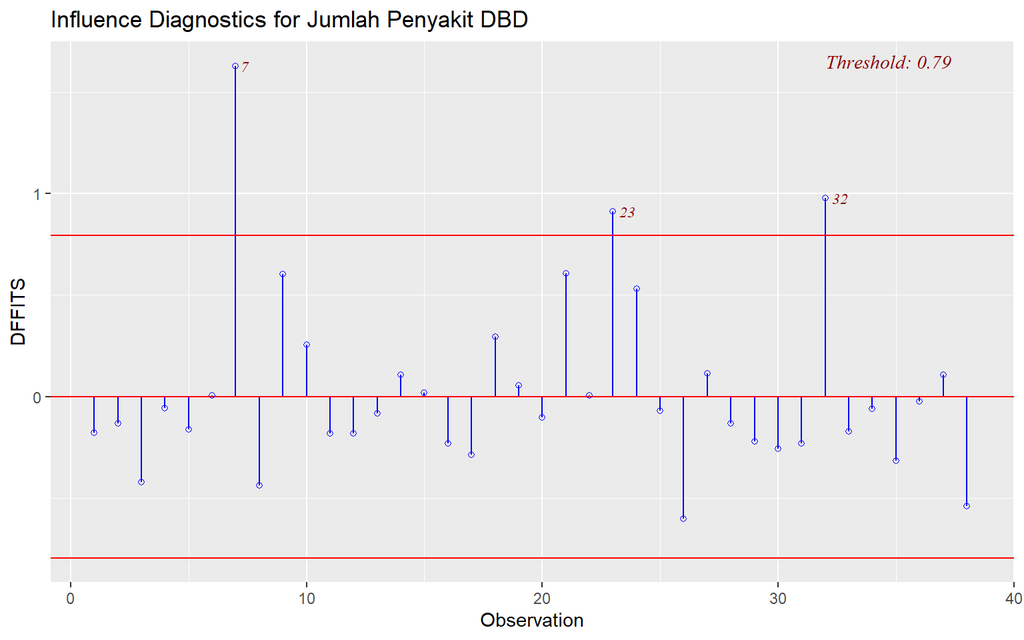

```r
ols_plot_dffits(model2)
```

Hasil DFFITS menunjukkan pengaruh observasi terhadap nilai prediksi Y, sehingga hanya menghasilkan satu output. DFFITS mengukur seberapa besar nilai prediksi $\hat{Y}_i$ berubah jika suatu observasi dihapus dari model, sehingga lebih tepat digunakan jika ingin melihat pengaruh observasi terhadap hasil model secara keseluruhan

```r
DFFITSi <- dffits(model2)

amatan_berpengaruh <- vector("list", dim(nilai)[1])
for (i in 1:dim(nilai)[1]) {
  cutoff <- 2 * sqrt((p / n))
  amatan_berpengaruh[[i]] <- which(abs(DFFITSi) > cutoff)
}
berpengaruh <- unlist(amatan_berpengaruh)
amatan_berpengaruh <- sort(unique(berpengaruh))
amatan_berpengaruh
```

```
## [1]  7 23 32
```

Amatan ke-7, 23, dan 32 termasuk amatan berpengaruh sehingga sangat riskan jika disisihkan. Perlu ditelusuri lebih lanjut

# Pemodelan Penyisihan Amatan

```r
dt1 <- dt %>% slice(-7)
model3 <- lm(
  `Jumlah Penyakit DBD` ~
    `Indeks Pembangunan Manusia` +
    `Persentase Penduduk Miskin` +
    `Persentase Memiliki Jaminan Kesehatan` +
    `Kepadatan Penduduk`,
  data = dt1
)

dt2 <- dt %>% slice(-23)
model4 <- lm(
  `Jumlah Penyakit DBD` ~
    `Indeks Pembangunan Manusia` +
    `Persentase Penduduk Miskin` +
    `Persentase Memiliki Jaminan Kesehatan` +
    `Kepadatan Penduduk`,
  data = dt2
)

dt3 <- dt %>% slice(-32)
model5 <- lm(
  `Jumlah Penyakit DBD` ~
    `Indeks Pembangunan Manusia` +
    `Persentase Penduduk Miskin` +
    `Persentase Memiliki Jaminan Kesehatan` +
    `Kepadatan Penduduk`,
  data = dt3
)

dt4 <- dt %>% slice(-c(7,23))
model6 <- lm(
  `Jumlah Penyakit DBD` ~
    `Indeks Pembangunan Manusia` +
    `Persentase Penduduk Miskin` +
    `Persentase Memiliki Jaminan Kesehatan` +
    `Kepadatan Penduduk`,
  data = dt4
)

dt5 <- dt %>% slice(-c(7,32))
model7 <- lm(
  `Jumlah Penyakit DBD` ~
    `Indeks Pembangunan Manusia` +
    `Persentase Penduduk Miskin` +
    `Persentase Memiliki Jaminan Kesehatan` +
    `Kepadatan Penduduk`,
  data = dt5
)

dt6 <- dt %>% slice(-c(23,32))
model8 <- lm(
  `Jumlah Penyakit DBD` ~
    `Indeks Pembangunan Manusia` +
    `Persentase Penduduk Miskin` +
    `Persentase Memiliki Jaminan Kesehatan` +
    `Kepadatan Penduduk`,
  data = dt6
)

dt7 <- dt %>% slice(-c(7,23,32))
model9 <- lm(
  `Jumlah Penyakit DBD` ~
    `Indeks Pembangunan Manusia` +
    `Persentase Penduduk Miskin` +
    `Persentase Memiliki Jaminan Kesehatan` +
    `Kepadatan Penduduk`,
  data = dt7
)
```

```r
get_metrics <- function(model) {
  adj_r2 <- summary(model)$adj.r.squared
  sse <- sum(model$residuals^2)
  return(c(adj_r2, sse))
}

model_metrics <- data.frame(
  Model = c("Model 2", "Model 3", "Model 4", "Model 5", "Model 6",
            "Model 7", "Model 8", "Model 9"),
  Adjusted_R2 = sapply(list(model2, model3, model4, model5,
                            model6, model7, model8, model9),
                       function(m) get_metrics(m)[1]),
  SSE = sapply(list(model2, model3, model4, model5,
                    model6, model7, model8, model9),
               function(m) get_metrics(m)[2])
)

print(model_metrics)
```

```
##     Model Adjusted_R2       SSE
## 1 Model 2 -0.01772755 1624689.6
## 2 Model 3  0.02130518  867953.3
## 3 Model 4  0.03907559 1495156.5
## 4 Model 5  0.09018950 1454813.1
## 5 Model 6  0.01248608  775167.4
## 6 Model 7  0.17955601  682599.2
## 7 Model 8  0.10338159 1349900.5
## 8 Model 9  0.15563857  613361.6
```

Berdasarkan hasil perbandingan tersebut, didapatkan bahwa model 7 yang menyisihkan amatan ke-7 dan ke-32 memiliki nilai adjusted R square terbesar, yaitu sebesar 0,1796, yang menunjukkan bahwa model tersebut mampu menjelaskan keragaman data lebih baik dibandingkan model lainnya. Namun, model 7 bukan merupakan model dengan SSE terkecil. Nilai SSE terkecil diperoleh pada model 9 yang menyisihkan amatan ke-7, ke-23, dan ke-32, yaitu sebesar 613.361,6. Nilai SSE yang lebih kecil menunjukkan bahwa jumlah kuadrat sisaan yang dihasilkan model lebih rendah sehingga model memiliki galat prediksi yang lebih kecil dibandingkan model-model lainnya. Dengan demikian, model 7 unggul berdasarkan kriteria adjusted R square, sedangkan model 9 unggul berdasarkan kriteria SSE. Oleh karena itu, pemilihan model terbaik perlu mempertimbangkan tujuan analisis, apakah lebih mengutamakan kemampuan model dalam menjelaskan keragaman data (adjusted R square) atau ketepatan prediksi yang ditunjukkan oleh nilai SSE yang lebih kecil.

```r
stargazer(model2, model4, model9, type = "text", font.size = "small",
          report = "vc*p")
```

```
##
## =========================================================================================================
##                                                                    Dependent variable:
##                                                 ---------------------------------------------------------
##                                                                   `Jumlah Penyakit DBD`
##                                                        (1)                (2)                 (3)
## ---------------------------------------------------------------------------------------------------------
## `Indeks Pembangunan Manusia`                         -14.331            -12.570             -16.380
##                                                     p = 0.452          p = 0.481           p = 0.174
##
## `Persentase Penduduk Miskin`                         -15.733            -21.244             -12.651
##                                                     p = 0.314          p = 0.157           p = 0.207
##
## `Persentase RT terhadap Sumber Air Minum Layak`       1.829
##                                                     p = 0.837
##
## `Persentase Memiliki Jaminan Kesehatan`               -0.611             -2.195              0.653
##                                                     p = 0.808          p = 0.382           p = 0.705
##
## `Kepadatan Penduduk`                                  -0.020             -0.018             -0.023
##                                                     p = 0.418          p = 0.445           p = 0.163
##
## Constant                                            1,478.892          1,673.496          1,647.245*
##                                                     p = 0.415          p = 0.217           p = 0.073
##
## ---------------------------------------------------------------------------------------------------------
## Observations                                            38                 37                 35
## R2                                                    0.120              0.146               0.255
## Adjusted R2                                           -0.018             0.039               0.156
## Residual Std. Error                             225.325 (df = 32)  216.157 (df = 32)   142.987 (df = 30)
## F Statistic                                     0.871 (df = 5; 32) 1.366 (df = 4; 32) 2.567* (df = 4; 30)
## =========================================================================================================
## Note:                                                                         *p<0.1; **p<0.05; ***p<0.01
```